# R Homework

Fernando Silva Aguilar

October 11, 2017

**Note from review:** The code works almost perfect, congratulations. It was necessary to mask (comment) the `setwd` command from your chunks to make the code work. There is one error message in the last chunk. Nice job!

# Data load

- First we start by reading the files directly from github.
- To do so, we enter into [fang_et_at_genotypes](https://raw.githubusercontent.com/fsilvaag/BCB546X-Fall2017/master/UNIX_Assignment/fang_et_al_genotypes.txt) for the file Fancg_et_al_Genotypes.txt and [SNP_position](https://raw.githubusercontent.com/EEOB-BioData/BCB546X-Fall2017/master/UNIX_Assignment/snp_position.txt) for the file SNP_Position.

```r
Genotypes <- read.delim("https://raw.githubusercontent.com/fsilvaag/BCB546X-Fall2017/master/UNIX_Assignment/fang_et_al_genotypes.txt", header=TRUE)
SNP_position <- read.delim("https://raw.githubusercontent.com/EEOB-BioData/BCB546X-Fall2017/master/UNIX_Assignment/snp_position.txt", header=TRUE)
```

# DATA INSPECTION:

- First we type head() to have a look of the files. For small or medium data.frame we can use instead View(file), but for large data.frame this could take a long time.

```r
head(Genotypes, 2, n=5)
```

|  | Sample_ID | JG_OTU | Group | abph1.20 | abph1.22 | ae1.3 | ae1.4 | ae1.5 | an1.4 | ba1.6 | ba1.9 | bt2.5 | bt2.7 | bt2.8 | Fea2.1 | Fea2.5 | id1.3 | lg2.11 | lg2.2 | pbf1.1 | pbf1.2 | pbf1.3 | pbf1.5 | pbf1.6 | pbf1.7 | pbf1.8 | PZA00003.11 | PZA00004.2 | PZA00005.8 | … |
| --- | --- | --- | --- | --- | --- | --- | --- | --- | --- | --- | --- | --- | --- | --- | --- | --- | --- | --- | --- | --- | --- | --- | --- | --- | --- | --- | --- | --- | --- | --- |
| 1 | SL-15 | T-aust-1 | TRIPS | ?/? | ?/? | T/T | G/G | T/T | C/C | ?/? | G/G | ?/? | A/A | ?/? | C/C | A/A | T/T | C/C | A/A | ?/? | ?/? | ?/? | ?/? | ?/? | C/C | C/C | ?/? | T/T | G/G | … |
| 2 | SL-16 | T-aust-2 | TRIPS | ?/? | ?/? | T/T | ?/? | T/T | C/C | A/G | G/G | ?/? | A/A | ?/? | C/C | A/A | T/T | C/C | A/A | T/T | ?/? | ?/? | ?/? | ?/? | C/C | C/C | ?/? | T/T | G/G | … |
| 3 | SL-11 | T-brav-1 | TRIPS | ?/? | ?/? | T/T | G/G | T/T | ?/? | G/G | G/G | C/C | A/A | ?/? | ?/? | A/A | T/T | C/C | A/A | T/T | ?/? | ?/? | A/A | ?/? | C/C | C/C | C/C | ?/? | G/G | … |
| 4 | SL-12 | T-brav-2 | TRIPS | ?/? | ?/? | T/T | G/G | T/T | C/C | G/G | G/G | C/C | A/A | ?/? | ?/? | A/A | T/T | C/C | A/A | T/T | ?/? | ?/? | A/A | ?/? | C/C | C/C | ?/? | T/T | G/G | … |
| 5 | SL-18 | T-cund | TRIPS | ?/? | ?/? | T/T | G/G | T/T | C/C | ?/? | G/G | ?/? | A/A | ?/? | C/C | A/A | T/T | C/C | A/A | T/T | ?/? | ?/? | ?/? | ?/? | C/C | C/C | C/C | T/T | G/G | … |

```r
head(SNP_position, n=5)
```

|  | SNP_ID | cdv_marker_id | Chromosome | Position | alt_pos | mult_positions | amplicon | cdv_map_feature.name | gene | candidate.random | Genaissance_daa_id | Sequenom_daa_id | count_amplicons | count_cmf | count_gene |
| --- | --- | --- | --- | --- | --- | --- | --- | --- | --- | --- | --- | --- | --- | --- | --- |
| 1 | abph1.20 | 5976 | 2 | 27403404 |  |  | abph1 | AB042260 | abph1 | candidate | 8393 | 10474 | 1 | 1 | 1 |
| 2 | abph1.22 | 5978 | 2 | 27403892 |  |  | abph1 | AB042260 | abph1 | candidate | 8394 | 10475 | 0 | 0 | 0 |
| 3 | ae1.3 | 6605 | 5 | 167889790 |  |  | ae1 | ae1 | ae1 | candidate | 8395 | 10477 | 1 | 1 | 1 |
| 4 | ae1.4 | 6606 | 5 | 167889682 |  |  | ae1 | ae1 | ae1 | candidate | 8396 | 10478 | 0 | 0 | 0 |
| 5 | ae1.5 | 6607 | 5 | 167889821 |  |  | ae1 | ae1 | ae1 | candidate | 8397 | 10479 | 0 | 0 | 0 |

- We have for both files a structure of a list.

```r
typeof(Genotypes)
```

```
[1] "list"
```

```r
typeof(SNP_position)
```

```
[1] "list"
```

- Equally we have that both files are a data.frame according to the function class. For Genotype file we have all variables as factors, while for SNP_position we have some variables as a integer.

```r
class(Genotypes)
```

```
[1] "data.frame"
```

```r
class(SNP_position)
```

```
[1] "data.frame"
```

```r
str(Genotypes)
```

```
'data.frame':   2782 obs. of  986 variables:
 $ Sample_ID     : Factor w/ 2782 levels "BKN_001","BKN_002",..: 445 446 442 443 448 450 457 459 460 458 ...
 $ JG_OTU        : Factor w/ 2782 levels "T-aust-1","T-aust-2",..: 1 2 3 4 5 6 7 8 9 10 ...
 $ Group         : Factor w/ 16 levels "TRIPS","ZDIPL",..: 1 1 1 1 1 1 1 1 1 1 ...
 $ abph1.20      : Factor w/ 4 levels "?/?","C/C","C/G",..: 1 1 1 1 1 1 1 1 1 1 ...
 $ abph1.22      : Factor w/ 4 levels "?/?","A/A","A/C",..: 1 1 1 1 1 1 1 1 1 1 ...
 $ ae1.3         : Factor w/ 4 levels "?/?","G/G","G/T",..: 4 4 4 4 4 4 4 4 4 4 ...
 $ ae1.4         : Factor w/ 4 levels "?/?","A/A","A/G",..: 4 1 4 4 4 4 4 4 4 4 ...
 $ ae1.5         : Factor w/ 4 levels "?/?","C/C","C/T",..: 4 4 4 4 4 4 4 4 4 4 ...
 $ an1.4         : Factor w/ 4 levels "?/?","C/C","C/G",..: 2 2 1 2 2 2 2 2 2 2 ...
 $ ba1.6         : Factor w/ 4 levels "?/?","A/A","A/G",..: 1 3 4 4 1 3 4 1 4 1 ...
 $ ba1.9         : Factor w/ 4 levels "?/?","G/G","G/T",..: 2 2 2 2 2 2 2 2 2 2 ...
 $ bt2.5         : Factor w/ 4 levels "?/?","C/C","C/T",..: 1 1 2 2 1 1 1 1 1 1 ...
 $ bt2.7         : Factor w/ 4 levels "?/?","A/A","A/G",..: 2 2 2 2 2 2 2 2 2 2 ...
 $ bt2.8         : Factor w/ 4 levels "?/?","A/A","A/G",..: 1 1 1 1 1 1 1 1 1 1 ...
```

[output cut: 86 more lines]

```r
str(SNP_position)
```

```
'data.frame':   983 obs. of  15 variables:
 $ SNP_ID              : Factor w/ 983 levels "abph1.20","abph1.22",..: 1 2 3 4 5 6 7 8 9 10 ...
 $ cdv_marker_id       : int  5976 5978 6605 6606 6607 5982 3463 3466 5983 5985 ...
 $ Chromosome          : Factor w/ 12 levels "1","10","2","3",..: 3 3 6 6 6 1 4 4 5 5 ...
 $ Position            : Factor w/ 942 levels "","100227859",..: 624 625 334 333 335 577 396 395 840 842 ...
 $ alt_pos             : Factor w/ 7 levels "","Approximate: 5 prime BLAST start of amplicon plus 150 bases",..: 1 1 1 1 1 1 1 1 1 1 ...
 $ mult_positions      : Factor w/ 18 levels "","Chr1(275076660);Chr8(71078729);",..: 1 1 1 1 1 1 1 1 1 1 ...
 $ amplicon            : Factor w/ 567 levels "abph1","ae1",..: 1 1 2 2 2 3 4 4 5 5 ...
 $ cdv_map_feature.name: Factor w/ 539 levels "AB042260","ae1",..: 1 1 2 2 2 10 443 443 472 472 ...
 $ gene                : Factor w/ 547 levels "abph1","ae1",..: 1 1 2 2 2 10 463 463 472 472 ...
 $ candidate.random    : Factor w/ 2 levels "candidate","random": 1 1 1 1 1 1 1 1 1 1 ...
 $ Genaissance_daa_id  : int  8393 8394 8395 8396 8397 8398 8399 8400 8401 8402 ...
 $ Sequenom_daa_id     : int  10474 10475 10477 10478 10479 10481 10482 10483 10486 10487 ...
 $ count_amplicons     : int  1 0 1 0 0 1 1 0 1 0 ...
 $ count_cmf           : int  1 0 1 0 0 1 0 0 1 0 ...
 $ count_gene          : int  1 0 1 0 0 1 1 0 1 0 ...
```

- The Genotype file has 2782 number of rows and 986 number of columns, while the SNP_position has 983 rows with 15 columns.

```r
dim(Genotypes)
```

```
[1] 2782  986
```

```r
dim(SNP_position)
```

```
[1] 983  15
```

- The name of each column per file is given by colnames function.

```r
colnames(Genotypes)
```

```
  [1] "Sample_ID"      "JG_OTU"
  [3] "Group"          "abph1.20"
  [5] "abph1.22"       "ae1.3"
  [7] "ae1.4"          "ae1.5"
  [9] "an1.4"          "ba1.6"
 [11] "ba1.9"          "bt2.5"
 [13] "bt2.7"          "bt2.8"
 [15] "Fea2.1"         "Fea2.5"
 [17] "id1.3"          "lg2.11"
 [19] "lg2.2"          "pbf1.1"
 [21] "pbf1.2"         "pbf1.3"
 [23] "pbf1.5"         "pbf1.6"
 [25] "pbf1.7"         "pbf1.8"
 [27] "PZA00003.11"    "PZA00004.2"
 [29] "PZA00005.8"     "PZA00005.9"
```

[output cut: 478 more lines]

```r
colnames(SNP_position)
```

```
 [1] "SNP_ID"               "cdv_marker_id"
 [3] "Chromosome"           "Position"
 [5] "alt_pos"              "mult_positions"
 [7] "amplicon"             "cdv_map_feature.name"
 [9] "gene"                 "candidate.random"
[11] "Genaissance_daa_id"   "Sequenom_daa_id"
[13] "count_amplicons"      "count_cmf"
[15] "count_gene"
```

- To investigate the levels per column in each file we can use the levels() function. For example, for the SNP_position data.frame we have 12 levels going from 1 to 10 and including multiple and unknown. Additionally we can appreciate that for the Genotype data.frame we have 16 levels for the group column

```r
levels(SNP_position$Chromosome)
```

```
 [1] "1"        "10"       "2"        "3"
 [5] "4"        "5"        "6"        "7"
 [9] "8"        "9"        "multiple" "unknown"
```

```r
levels(Genotypes$Group)
```

```
 [1] "TRIPS" "ZDIPL" "ZLUXR" "ZMHUE" "ZMMIL" "ZMMLR"
 [7] "ZMMMR" "ZMPBA" "ZMPIL" "ZMPJA" "ZMXCH" "ZMXCP"
[13] "ZMXIL" "ZMXNO" "ZMXNT" "ZPERR"
```

# DATA PROCESING

## Data Split in Groups

- To create the files for Maize, Teosinte, and Tripsacum, we can use the function subset with the logical condition “or” (|). However, for tripsacum we have to work with the logical condition “and” (&) and the opposite condition (!), as follows:

```r
maize <- subset(Genotypes, Group == "ZMMIL" | Group == "ZMMLR" | Group =="ZMMMR")
teosinte <- subset(Genotypes, Group == "ZMPBA" | Group == "ZMPIL" | Group == "ZMPJA")
tripsacum <- subset(Genotypes, !Group == "ZMPBA" & !Group == "ZMPIL" & !Group == "ZMPJA" & !Group == "ZMMIL" & !Group == "ZMMLR" & !Group=="ZMMMR")
```

## Data transposing

- To transpose the data we can use the function t, as follows.

```r
transposed_maize <- as.data.frame(t(maize))
transposed_teosinte <- as.data.frame(t(teosinte))
```

The new data.frame has the problem that the header was not included in the first column, so we load a library(tibble) and include the row names as our first column and include the first row as the header in the new data.frames.

```r
if(!require("tibble")) install.packages("tibble")
library(tibble)
names(transposed_maize) <- lapply(transposed_maize[1, ], as.character)
transposed_maize <- transposed_maize[-1,]
names(transposed_teosinte) <- lapply(transposed_teosinte[1, ], as.character)
transposed_teosinte <- transposed_teosinte[-1,]
transposed_maize <- rownames_to_column(transposed_maize, var="SNP_ID")
transposed_teosinte <- rownames_to_column(transposed_teosinte, var="SNP_ID")
```

In the data.frame snp_position the column 3 is for chromosome, the position of the chromosome is the column 4, while the column 1 (SNP_ID) is the common column with the transposed files. Then, we proceed to create a new file with only the information required from the snp_position.txt file:

```r
snp_ID_chro_pos <- SNP_position[, c("SNP_ID", "Chromosome", "Position")]
```

Once we have the new data.frame we proceed to order the data.frames of the transposed files as follows:

```r
if(!require("dplyr")) install.packages("dplyr")
library(dplyr)
transposed_teosinte <- arrange(transposed_teosinte, SNP_ID)
transposed_maize <- arrange(transposed_maize, SNP_ID)
snp_ID_chro_pos <- arrange(snp_ID_chro_pos, SNP_ID)
```

Now that we have sorted the files by snp_ID, we can proceed to join them with the information of the SNP position, and chromosome:

```r
teosinte_all_join <- merge(snp_ID_chro_pos,transposed_teosinte, by.x="SNP_ID", by.y="SNP_ID", all = TRUE)
maize_all_join <- merge(snp_ID_chro_pos,transposed_maize, by.x="SNP_ID", by.y="SNP_ID", all = TRUE)
#NOTE: we can avoid the steps in which we include the column and header to the transposed data.frame, by using in the merge statement the by.y="row.names".
```

```r
teosinte_all_join <- subset(teosinte_all_join, !(teosinte_all_join$Chromosome == "unknown") | !(teosinte_all_join$Chromosome =="multiple"))
maize_all_join <- subset(maize_all_join, !(maize_all_join$Chromosome == "unknown") | !(maize_all_join$Chromosome == "multiple"))
```

```r
teosinte_all_join <- arrange(teosinte_all_join, Position)
maize_all_join <- arrange(maize_all_join, Position)
```

```r
#set the directory in which you want to save the files in my local computer I want the following directory
#setwd("C:/Users/fsilvaag/Documents/ISU COURSES/2017/fall/BCB546X-Fall2017/R_Lessons/Files")
teosinte_split <- split(teosinte_all_join, teosinte_all_join$Chromosome)
nom <- names(teosinte_split)
for(myname in nom){
  savename = paste0('Teosinte_Chr_', myname, '.txt')
write.table(teosinte_split[[myname]], file = savename, quote = FALSE, sep = "\t", row.names = FALSE)
}
maize_split <- split(maize_all_join, maize_all_join$Chromosome)
nom <- names(maize_split)
for(myname in nom){
  savename = paste0('Maize_Chr_', myname, '.txt')
write.table(maize_split[[myname]], file = savename, quote = FALSE, sep = "\t", row.names = FALSE)
}
```

- So far we have the data with the default missing command ?.

## Changing the missing code ? for -

- We order the dataframe in a decreasing order. After that we have to said R that the values inside the data.frame are characters so we can look for the ? and replace it for -:

```r
# Ordering the data.frame in an decreasing order
rev_teosinte_all_join <- arrange(teosinte_all_join, desc(Position))
rev_maize_all_join <- arrange(maize_all_join, desc(Position))
# Changing the symbol ? by -
rev_teosinte_all_join[] <- lapply(rev_teosinte_all_join, as.character)
rev_teosinte_all_join[rev_teosinte_all_join == '?/?'] <- '-/-'
rev_maize_all_join[] <- lapply(rev_maize_all_join, as.character)
rev_maize_all_join[rev_maize_all_join == '?/?'] <- '-/-'
```

- Once we have the data sorted and with the symbol - instead of ?, we proceed to create the files per chromosome.

```r
#set the directory in which you want to save the files in my local computer I want the following directory
#setwd("C:/Users/fsilvaag/Documents/ISU COURSES/2017/fall/BCB546X-Fall2017/R_Lessons/Files")
rev_teosinte_split <- split(rev_teosinte_all_join, rev_teosinte_all_join$Chromosome)
nom <- names(rev_teosinte_split)
for(myname in nom){
  savename = paste0('Rev_teosinte_Chr_', myname, '.txt')
write.table(rev_teosinte_split[[myname]], file = savename, quote = FALSE, sep = "\t", row.names = FALSE)
}
rev_maize_split <- split(rev_maize_all_join, rev_maize_all_join$Chromosome)
nom <- names(rev_maize_split)
for(myname in nom){
  savename = paste0('Rev_Maize_Chr_', myname, '.txt')
write.table(rev_maize_split[[myname]], file = savename, quote = FALSE, sep = "\t", row.names = FALSE)
}
```

# PART II

- First we load the packages

```r
if (!require("ggplot2")) install.packages("ggplot2")
library(ggplot2)
if(!require("tibble")) install.packages("tibble")
library(tibble)
if (!require("reshape2")) install.packages("reshape2")
library(reshape2)
if(!require("dplyr")) install.packages("dplyr")
library(dplyr)
if (!require("plyr")) install.packages("plyr")
library(plyr)
```

- Now we have to work with the original file Genotypes and make the merge with the SNP posistion.

```r
transpose_genotypes <- as.data.frame(t(Genotypes))
#This is to create again the header as the sample ID and to include the first column wich is the row names
names(transpose_genotypes) <- lapply(transpose_genotypes[1, ], as.character)
transpose_genotypes <- transpose_genotypes[-1,]
transpose_genotypes <- rownames_to_column(transpose_genotypes, var="SNP_ID")
#Merging the files SNP_position and transpose_genotypes
trans_genotype_join <- merge(SNP_position,transpose_genotypes, by.x="SNP_ID", by.y="SNP_ID", all = TRUE)
```

- Now I have created my new dataframe to start to plot.

### Plot of Total SNPs per chromosome and importance of each group

- First we have to produce create a vector for the chromosomes in order to have a graph in order.

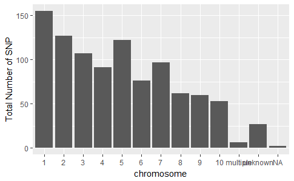

```r
# Ordering the chromosomes
trans_genotype_join$Chromosome <- factor(trans_genotype_join$Chromosome, levels = c("1", "2", "3", "4", "5", "6", "7", "8", "9", "10", "multiple", "unknown", "NA"))
#Creating the graph
ggplot(trans_genotype_join) + geom_bar(aes(trans_genotype_join$Chromosome)) + xlab("chromosome") + ylab("Total Number of SNP")
```

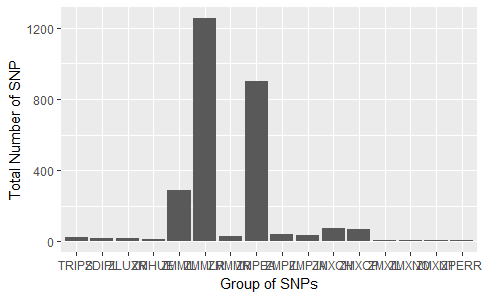

```r
#Creating the graph for the significance of each group of SNP (With the original data of (Fang_et_al_genotypes)
ggplot(Genotypes) + geom_bar(aes(Genotypes$Group)) + xlab("Group of SNPs") + ylab("Total Number of SNP")
```

## Missing data and amount of heterozygosity

- With the melt function we put the individual value of each SNP in each of the sample_ID and JG_OTU.

```r
header <- colnames(Genotypes)[-c(1:3)]
genotypes_melted <- melt(Genotypes, measure.vars = header)
```

```
attributes are not identical across measure variables; they will be dropped
```

- To change the sybol of missing data from ? to NA

```r
genotypes_melted[genotypes_melted == "?/?"] = NA
```

- Creation of a new column for homozygotes by creating a logical value of TRUE or FALSE and NA for the missing data. Then we sort the data.

```r
genotypes_melted$Homozygote <- (genotypes_melted$value == "A/A" | genotypes_melted$value == "C/C" | genotypes_melted$value == "T/T" | genotypes_melted$value == "G/G")
#SORTING THE DATA
genotypes_melted <- arrange(genotypes_melted, Sample_ID, Group)
```

### Plot of Homozygotes and Heterozygotes per sample_ID

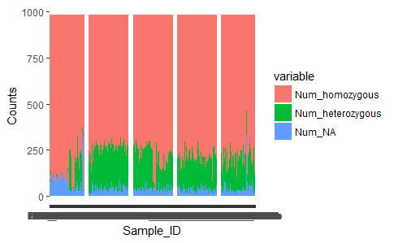

```r
Counts_ID <- ddply(genotypes_melted, c("Sample_ID"), summarise, Num_homozygous=sum(Homozygote, na.rm=TRUE), Num_heterozygous=sum(!Homozygote, na.rm=TRUE), Num_NA=sum(is.na(Homozygote)))
counts_ID_melted <- melt(Counts_ID, measure.vars = c("Num_homozygous", "Num_heterozygous", "Num_NA"))
colnames(counts_ID_melted)[3] <- "Counts"
ggplot(counts_ID_melted, aes(x = Sample_ID, y= Counts, fill=variable)) + geom_bar(stat = "identity", position = "stack")
```

### Plot of Homozygotes and Heterozygotes per Group

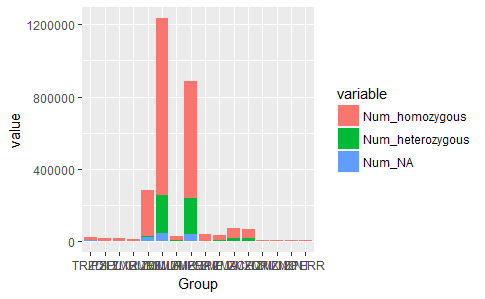

```r
Counts_group <- ddply(genotypes_melted, c("Group"), summarise, Num_homozygous=sum(Homozygote, na.rm=TRUE), Num_heterozygous=sum(!Homozygote, na.rm=TRUE), Num_NA=sum(is.na(Homozygote)))
counts_Group_melted <- melt(Counts_group, measure.vars = c("Num_homozygous", "Num_heterozygous", "Num_NA"))
ggplot(counts_Group_melted, aes(x = Group, y= value, fill=variable)) + geom_bar(stat = "identity", position = "stack")
```

```r
Heterozy_per_Locus <- ddply(genotypes_melted, c("Sample_ID"), summarise, heterozygocity_count=sum(!Homozygote, na.rm=TRUE), total_count=sum(!is.na(Heterozy_per_Locus)))
```

```
Error in eval(expr, envir, enclos) :
  object 'Heterozy_per_Locus' not found
```